# Subset Selection

Omar Hanley, Zachary Rosen, Todd Schaffer, and Yannan Zhu

January 29, 2020

# Lab 1: Subset Selection Methods

## Best Subset Selection

Exhaustively, all possible *p* predictors are fit with a least squares regression line with the goal of finding a “best” fit

### Preprocessing

As with any machine learning problem, we must first load packages, examine and preprocess the data

```r
rm(list=ls())
dim(Hitters)
[1] 322  20

sum(is.na(Hitters$Salary))
[1] 59
```

We have to remove NA values because they will not work with the regsubsets() function

```r
Hitters=na.omit(Hitters)
dim(Hitters)
[1] 263  20

sum(is.na(Hitters))
[1] 0
```

Finally, we have removed NA values and reduced the number of observations from 322 to 263

### Fitting A Model

We assign the model to the variable regfit.full and call the regsubsets() function to collectively exhaust all possible fits

```r
regfit.full = regsubsets(Salary~.,data =  Hitters)

summary(regfit.full)
Subset selection object
Call: regsubsets.formula(Salary ~ ., data = Hitters)
19 Variables  (and intercept)
           Forced in Forced out
AtBat          FALSE      FALSE
Hits           FALSE      FALSE
HmRun          FALSE      FALSE
Runs           FALSE      FALSE
RBI            FALSE      FALSE
Walks          FALSE      FALSE
Years          FALSE      FALSE
CAtBat         FALSE      FALSE
CHits          FALSE      FALSE
CHmRun         FALSE      FALSE
CRuns          FALSE      FALSE
CRBI           FALSE      FALSE
CWalks         FALSE      FALSE
LeagueN        FALSE      FALSE
DivisionW      FALSE      FALSE
PutOuts        FALSE      FALSE
Assists        FALSE      FALSE
Errors         FALSE      FALSE
NewLeagueN     FALSE      FALSE
1 subsets of each size up to 8
Selection Algorithm: exhaustive
         AtBat Hits HmRun Runs RBI Walks Years CAtBat CHits CHmRun CRuns
1  ( 1 ) " "   " "  " "   " "  " " " "   " "   " "    " "   " "    " "
2  ( 1 ) " "   "*"  " "   " "  " " " "   " "   " "    " "   " "    " "
3  ( 1 ) " "   "*"  " "   " "  " " " "   " "   " "    " "   " "    " "
4  ( 1 ) " "   "*"  " "   " "  " " " "   " "   " "    " "   " "    " "
5  ( 1 ) "*"   "*"  " "   " "  " " " "   " "   " "    " "   " "    " "
6  ( 1 ) "*"   "*"  " "   " "  " " "*"   " "   " "    " "   " "    " "
7  ( 1 ) " "   "*"  " "   " "  " " "*"   " "   "*"    "*"   "*"    " "
8  ( 1 ) "*"   "*"  " "   " "  " " "*"   " "   " "    " "   "*"    "*"
         CRBI CWalks LeagueN DivisionW PutOuts Assists Errors NewLeagueN
1  ( 1 ) "*"  " "    " "     " "       " "     " "     " "    " "
2  ( 1 ) "*"  " "    " "     " "       " "     " "     " "    " "
3  ( 1 ) "*"  " "    " "     " "       "*"     " "     " "    " "
4  ( 1 ) "*"  " "    " "     "*"       "*"     " "     " "    " "
5  ( 1 ) "*"  " "    " "     "*"       "*"     " "     " "    " "
6  ( 1 ) "*"  " "    " "     "*"       "*"     " "     " "    " "
7  ( 1 ) " "  " "    " "     "*"       "*"     " "     " "    " "
8  ( 1 ) " "  "*"    " "     "*"       "*"     " "     " "    " "
```

The default amount of predictors to be included in the regsubsets() function is 8. Hence the “1 subsets of each size up to 8” statement in the summary. Additionally, the asterisks indicate which features were chosen to best predict the response variable

Now, use the parameter nvmax=19 in the regsubsets() function to include all possible features

```r
regfit.full=regsubsets(Salary~.,data=Hitters,nvmax=19)
reg.summary=summary(regfit.full)

names(reg.summary)
[1] "which"  "rsq"    "rss"    "adjr2"  "cp"     "bic"    "outmat" "obj"
```

### Plotting the Data

Plot the number of variables against the error terms

- This allows you to visually notice where adding features/information becomes invaluable

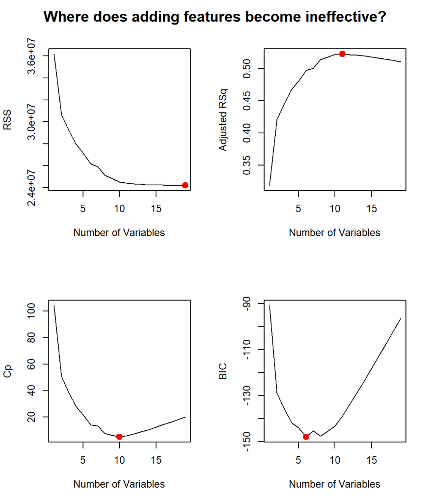

```r
par(mfrow=c(2,2))
plot(reg.summary$rss,xlab="Number of Variables",ylab="RSS",type="l")
points(which.min(reg.summary$rss),reg.summary$rss[which.min(reg.summary$rss)],
       col="red",cex=2,pch=20)
plot(reg.summary$adjr2,xlab="Number of Variables",ylab="Adjusted RSq",type="l")
points(which.max(reg.summary$adjr2),reg.summary$adjr2[which.max(reg.summary$adjr2)],
       col="red",cex=2,pch=20)
plot(reg.summary$cp,xlab="Number of Variables",ylab="Cp",type='l')
points(which.min(reg.summary$cp),reg.summary$cp[which.min(reg.summary$cp)],
       col="red",cex=2,pch=20)
plot(reg.summary$bic,xlab="Number of Variables",ylab="BIC",type='l')
points(which.min(reg.summary$bic),reg.summary$bic[which.min(reg.summary$bic)],
       col="red",cex=2,pch=20)
mtext("Where does adding features become ineffective?",
      side=3,line=-2,outer=TRUE, font=2, cex=1.25)
```

```r
which.min(reg.summary$rss)
[1] 19

which.max(reg.summary$adjr2)
[1] 11

which.min(reg.summary$cp)
[1] 10

which.min(reg.summary$bic)
[1] 6
```

Next, we will plot the error terms against their respective variables

- Black means the variable is included in the model associated with that level of error

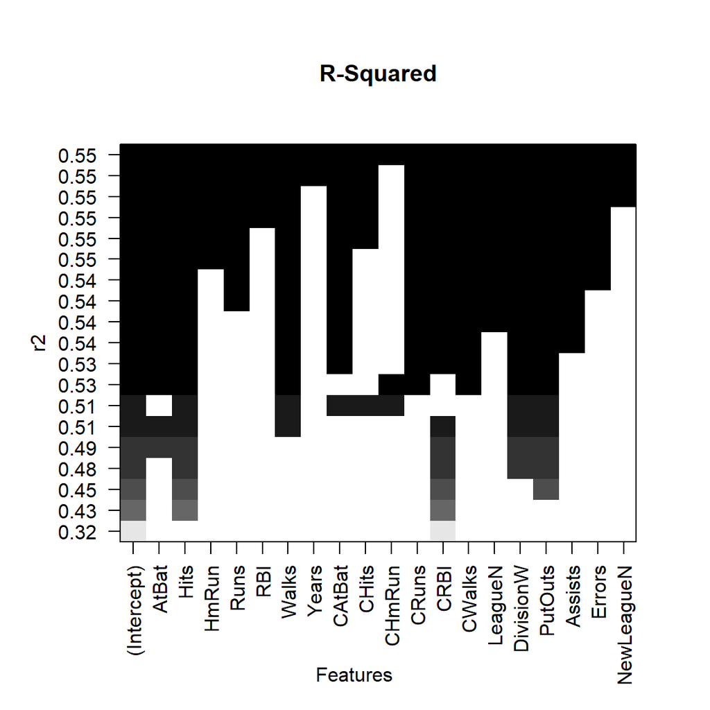

```r
### ask professor about which model to use and why
plot(regfit.full,scale="r2", main="R-Squared")
mtext("Features", side=1, line=-2, outer=TRUE)
```

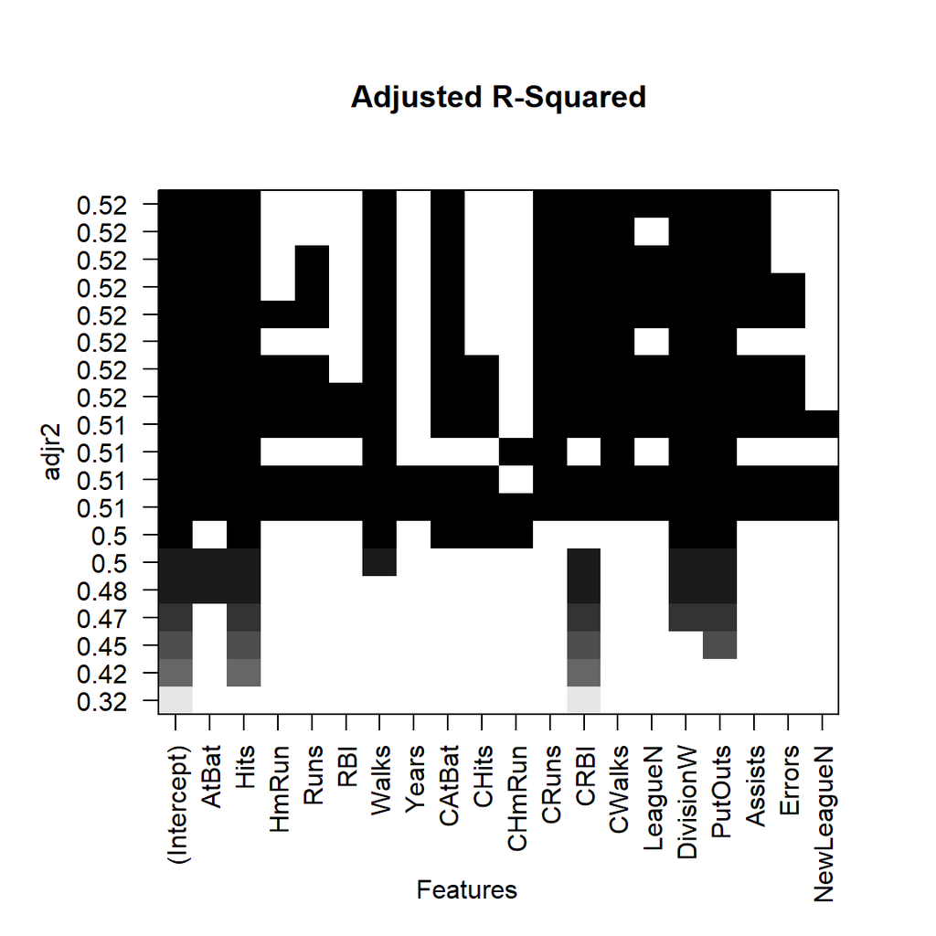

```r
plot(regfit.full,scale="adjr2", main="Adjusted R-Squared")
mtext("Features", side=1, line=-2, outer=TRUE)
```